# E07 - RNA-seq / 03 - exploratory analysis (Analysis of Gene Expression @ UCT Prague)

Copy, please, these files and directories to your personal directory:

```bash
cp -r ~/shared/AGE_current/Exercises/E07-RNA_seq/03_exploratory_analysis ~/AGE/Exercises/E07-RNA_seq
```

# Introduction

In the previous tutorial we learned how to go from raw RNA-seq reads to count matrix imported to R. We were using a subset of reads from the [airway experiment](https://www.ncbi.nlm.nih.gov/pubmed/24926665). However, a full version of this experiment is available in the [airway](https://bioconductor.org/packages/release/data/experiment/html/airway.html) package (as the `SummarizedExperiment` object). We will further work with this object.

In this exercise, you will reuse your functions in `age_library.R` again 😎

# Data preparation

Some vector/matrix operations can be speed-up by parallelization. Package [BiocParallel](http://bioconductor.org/packages/release/bioc/html/BiocParallel.html) offers parallelized versions of functions from the `apply` family. For example, parallelized version of `lapply()` is `bplapply()`. Many functions in `DESeq2` package can be run parallelized.

We create a `BPPARAM` variable containing information about parallelization parameters (2 cores), which we will reuse later. If we call `register()` with our `BPPARAM`, some packages (e.g. `DESeq2`) will then run parallelized automatically.

```r
library(here)
library(BiocParallel)

BPPARAM <- MulticoreParam(workers = 2)
register(BPPARAM)
```

Now let’s load the `SummarizedExperiment` object of the airway experiment data:

```r
library(magrittr)
library(airway)
library(conflicted)
conflict_prefer("rowRanges", "MatrixGenerics")
library(DESeq2)

source(here("age_library.R"))

data("airway")
se <- airway
se
```

```
## class: RangedSummarizedExperiment
## dim: 64102 8
## metadata(1): ''
## assays(1): counts
## rownames(64102): ENSG00000000003 ENSG00000000005 ... LRG_98 LRG_99
## rowData names(0):
## colnames(8): SRR1039508 SRR1039509 ... SRR1039520 SRR1039521
## colData names(9): SampleName cell ... Sample BioSample
```

```r
colData(se)
```

```
## DataFrame with 8 rows and 9 columns
##            SampleName     cell      dex    albut        Run avgLength Experiment    Sample    BioSample
##              <factor> <factor> <factor> <factor>   <factor> <integer>   <factor>  <factor>     <factor>
## SRR1039508 GSM1275862  N61311     untrt    untrt SRR1039508       126  SRX384345 SRS508568 SAMN02422669
## SRR1039509 GSM1275863  N61311     trt      untrt SRR1039509       126  SRX384346 SRS508567 SAMN02422675
## SRR1039512 GSM1275866  N052611    untrt    untrt SRR1039512       126  SRX384349 SRS508571 SAMN02422678
## SRR1039513 GSM1275867  N052611    trt      untrt SRR1039513        87  SRX384350 SRS508572 SAMN02422670
## SRR1039516 GSM1275870  N080611    untrt    untrt SRR1039516       120  SRX384353 SRS508575 SAMN02422682
## SRR1039517 GSM1275871  N080611    trt      untrt SRR1039517       126  SRX384354 SRS508576 SAMN02422673
## SRR1039520 GSM1275874  N061011    untrt    untrt SRR1039520       101  SRX384357 SRS508579 SAMN02422683
## SRR1039521 GSM1275875  N061011    trt      untrt SRR1039521        98  SRX384358 SRS508580 SAMN02422677
```

So far we have been working with four samples simply divided to `untrt` and `trt` groups (`trt` was dexamethasone). Now there is an additional division of samples by cell line (`cell` column).

You can see that the `se` object is an instance of class `RangedSummarizedExperiment`. In this object there is an additional list (`GRangesList`) holding genomic coordinates (`GRanges`) of rows (features - genes) of the count matrix (assay). `GRangesList` can be accessed by `rowRanges()` function:

```r
rowRanges(se)
```

```
## GRangesList object of length 64102:
## $ENSG00000000003
## GRanges object with 17 ranges and 2 metadata columns:
##        seqnames            ranges strand |   exon_id       exon_name
##           <Rle>         <IRanges>  <Rle> | <integer>     <character>
##    [1]        X 99883667-99884983      - |    667145 ENSE00001459322
##    [2]        X 99885756-99885863      - |    667146 ENSE00000868868
##    [3]        X 99887482-99887565      - |    667147 ENSE00000401072
##    [4]        X 99887538-99887565      - |    667148 ENSE00001849132
##    [5]        X 99888402-99888536      - |    667149 ENSE00003554016
##    ...      ...               ...    ... .       ...             ...
##   [13]        X 99890555-99890743      - |    667156 ENSE00003512331
##   [14]        X 99891188-99891686      - |    667158 ENSE00001886883
##   [15]        X 99891605-99891803      - |    667159 ENSE00001855382
##   [16]        X 99891790-99892101      - |    667160 ENSE00001863395
##   [17]        X 99894942-99894988      - |    667161 ENSE00001828996
##   -------
##   seqinfo: 722 sequences (1 circular) from an unspecified genome
##
## ...
## <64101 more elements>
```

You can see that `GRangesList` has a length of 64102 (= number of rows in `se`) and its names are ENSEMBL IDs. Each value is a `GRanges` object of genomics features of a gene.

We don’t go deeper now, for more information see `?RangedSummarizedExperiment`. I would just note that you can use `subset()` function to filter features based on `GRanges` columns (e.g. `start` or `end` - position on a chromoseme), and that could be handy.

Let’s go back to our experimental data. We want to be sure that `untrt` is the reference level for the `dex` variable:

```r
se$dex <- relevel(se$dex, "untrt")
se$dex
```

```
## [1] untrt trt   untrt trt   untrt trt   untrt trt
## Levels: untrt trt
```

From `se` object we can immediately create a `DESeqDataSet` object. We specify the model (design) such that `cell` and `dex` have additive effects:

```r
dds <- DESeqDataSet(se, design = ~ cell + dex)
```

Let’s annotate genes by using the code from the previous tutorial. Note that a custom function for this repeating code would be neat 🙂

```r
library(org.Hs.eg.db)
ann <- AnnotationDbi::select(org.Hs.eg.db, keys = rownames(dds), keytype = "ENSEMBL", columns = c("SYMBOL", "GENENAME"))
ann <- ann[!duplicated(ann$ENSEMBL), ]
rownames(ann) <- ann$ENSEMBL
ann <- ann[rownames(dds), ]
stopifnot(all(rownames(ann) == rownames(dds)))
rowData(dds) <- cbind(rowData(dds), ann)
rowData(dds) %>% head()
```

```
## DataFrame with 6 rows and 3 columns
##                         ENSEMBL      SYMBOL               GENENAME
##                     <character> <character>            <character>
## ENSG00000000003 ENSG00000000003      TSPAN6          tetraspanin 6
## ENSG00000000005 ENSG00000000005        TNMD            tenomodulin
## ENSG00000000419 ENSG00000000419        DPM1 dolichyl-phosphate m..
## ENSG00000000457 ENSG00000000457       SCYL3 SCY1 like pseudokina..
## ENSG00000000460 ENSG00000000460    C1orf112 chromosome 1 open re..
## ENSG00000000938 ENSG00000000938         FGR FGR proto-oncogene, ..
```

In RNA-seq, count matrices are usually quite sparse, i.e. some genes have zero counts in almost all samples. We can quickly remove these genes (rows), and consequently speed-up the analysis while also reducing the size of the object. We remove all rows having in total less than 10 counts across the samples:

```r
nrow(dds)
```

```
## [1] 64102
```

```r
dds <- dds[rowSums(counts(dds)) > 10, ]
nrow(dds)
```

```
## [1] 22008
```

BAM! More than half of the rows disappeared.

We can now prepare the `dds` object for the next steps. `DESeq()` function will do several things, shortly:

- The estimation of size factors, controlling for differences in the counts due varying sequencing depth of the samples. This is further explained in a section below.
- Fitting a final generalized linear model, which gives estimates of the log-fold changes and their associated statistics.

```r
dds <- DESeq(dds, parallel = TRUE)
```

# Count transformations

## Count normalization

*Some parts of the following text and images are taken from [here](https://github.com/hbctraining/DGE_workshop/blob/master/lessons/02_DGE_count_normalization.md).*

The counts of mapped reads for each gene is proportional to the expression of RNA (“interesting”) in addition to many other factors (“uninteresting”). Normalization is the process of scaling raw count values to account for the “uninteresting” factors. In this way the expression levels are more comparable between and/or within samples.

While normalization is essential for differential expression analyses, it is also necessary for exploratory data analysis, visualization of data, and whenever you are exploring or comparing counts between or within samples. **However, do not use normalized counts for differential expression testing. Packages for DE testing (such as `DESeq2`) expects raw counts and apply custom algorithms for normalization.**

You can read more about the impact of normalization methods to downstream analysis in [A protocol to evaluate RNA sequencing normalization methods (2019)](https://bmcbioinformatics.biomedcentral.com/articles/10.1186/s12859-019-3247-x)

### Normalization factors

The main factors often considered during normalization are:

#### Sequencing depth

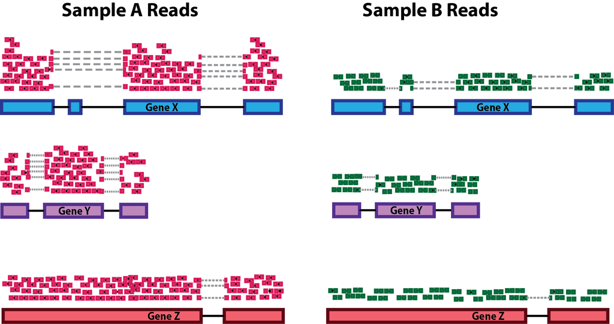

Accounting for sequencing depth is necessary for comparison of gene expression **between samples**. In the example below, each gene appears to have doubled in expression in *Sample A* relative to *Sample B*, however this is a consequence of *Sample A* having double the sequencing depth. **NOTE:** Each pink and green rectangle represents a read aligned to a gene. Reads connected by dashed lines represent reads spanning an intron.

#### Gene length

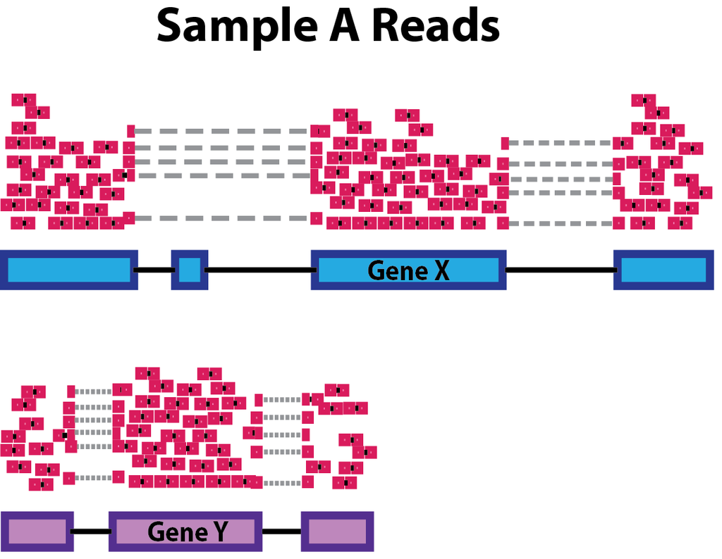

Accounting for gene length is necessary for comparing expression **between different genes within the same sample**. In the example, *Gene X* and *Gene Y* have similar levels of expression, but the number of reads mapped to *Gene X* would be many more than the number mapped to *Gene Y* because *Gene X* is longer.

#### RNA composition

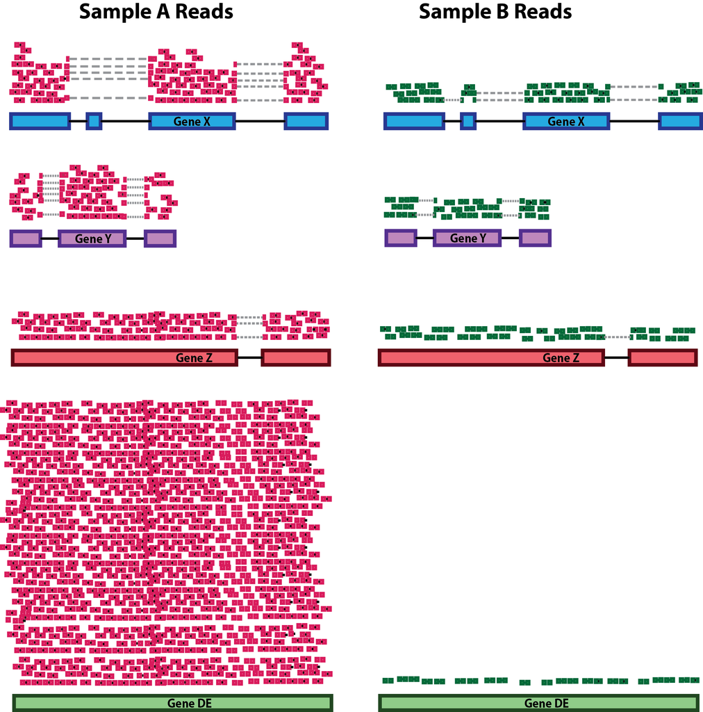

A few highly differentially expressed genes between samples, differences in the number of genes expressed between samples, or presence of contamination can skew some types of normalization methods. Accounting for RNA composition is recommended for accurate comparison of expression between samples, and is particularly important when performing differential expression analyses ([source](https://genomebiology.biomedcentral.com/articles/10.1186/gb-2010-11-10-r106)). In the example, if we were to divide each sample by the total number of counts to normalize, the counts would be greatly skewed by the DE gene, which takes up most of the counts for *Sample A*, but not *Sample B*. Most other genes for *Sample A* would be divided by the larger number of total counts and appear to be less expressed than those same genes in *Sample B*.

### Common normalization methods

Several common normalization methods exist to account for these differences:

| Normalization method | Description | Accounted factors | Recommendations for use |
| --- | --- | --- | --- |
| **CPM/FPM** (counts/fragments per million) | read counts/fragments scaled by total number of reads/fragments | sequencing depth | gene count comparisons between replicates of the same sample group; **NOT for within sample comparisons or DE analysis** |
| **TPM** (transcripts per kilobase million) | counts per length of transcript (kb) per million reads mapped | sequencing depth and gene length | gene count comparisons within a sample or between samples of the same sample group; **NOT for DE analysis** |
| **RPKM/FPKM** (reads/fragments per kilobase of exon per million reads/fragments mapped) | similar to TPM, but **the total number of RPKM/FPKM normalized counts for each sample will be different** | sequencing depth and gene length | gene count comparisons between genes within a sample; **NOT for between sample comparisons or DE analysis** |
| DESeq2’s **median of ratios** | counts divided by sample-specific size factors determined by median ratio of gene counts relative to geometric mean per gene | sequencing depth and RNA composition | gene count comparisons between samples and for **DE analysis**; **NOT for within sample comparisons** |

> $i$ in the formulas below refers to a single gene

### Between sample comparison of the same gene

For between sample comparison, we have to estimate library size, i.e. sequencing depth.

#### Counts/fragments per million (CPM/FPM)

Counts/fragments per million (CPM/FPM) mapped reads/fragments are counts ($C_i$) scaled by the number of reads/fragments you sequenced ($N$) times one million. This unit is related to the FPKM without length normalization and a factor of $10^3$:

$$CPM_i = \frac{C_i}{\frac{N}{10^6}} =
\frac{C_i}{N} \cdot 10^6$$

This is the most simple normalization accounting only for sequencing depth. It is usable only for gene count comparisons between replicates of the same sample group where significant changes in gene expression are not expected.

#### DESeq2-normalized counts: Median of ratios method

Since tools for differential expression analysis are comparing the counts between sample groups for the same gene, gene length does not need to be accounted for by the tool. However, **sequencing depth** and **RNA composition** do need to be taken into account.

To normalize for sequencing depth and RNA composition, `DESeq2` uses the median of ratios method. On the user-end there is only one step, but on the back-end there are multiple steps involved, as described below.

> The steps below describe in detail some of the steps performed by DESeq2 when you run a single function to get DE genes. Basically, for a typical RNA-seq analysis, **you would not run these steps individually**.

**Step 1: create a pseudo-reference sample (row-wise geometric mean)**

For each gene, a pseudo-reference sample is created that is equal to the geometric mean across all samples.

[output not shown]

**Step 2: calculates ratio of each sample to the reference**

For every gene in a sample, the ratios (sample/pseudo-reference) are calculated (as shown below). This is performed for each sample in the dataset. **Since the majority of genes are not differentially expressed, the majority of genes in each sample should have similar ratios within the sample.**

[output not shown]

**Step 3: calculate the size factor for each sample**

The median value (column-wise for the above table) of all ratios for a given sample is taken as the size factor (also called “normalization factor”) for that sample, as calculated below. Notice that the differentially expressed genes should not affect the median value:

```r
(normalization_factor_sampleA <- median(c(1.28, 1.3, 1.39, 1.35, 0.59)))
```

```
## [1] 1.3
```

```r
(normalization_factor_sampleB <- median(c(0.78, 0.77, 0.72, 0.74, 1.35)))
```

```
## [1] 0.77
```

The median of ratios method makes the assumption that **not ALL genes are differentially expressed**; therefore, the size factors should account for sequencing depth and RNA composition of the sample (large outlier genes will not represent the median ratio values). **This method is robust to imbalance in up-/down-regulation and large numbers of differentially expressed genes.**

> Usually these size factors are around 1, if you see large variations between samples it is important to take note since it might indicate the presence of extreme outliers.

**Step 4: calculate the normalized count values using the size factors**

This is performed by dividing each raw count value in a given sample by that sample’s size factor to generate normalized count values. This is performed for all count values (every gene in every sample). For example, if the median ratio for SampleA was 1.3 and the median ratio for SampleB was 0.77, you could calculate normalized counts as follows:

SampleA median ratio = 1.3

SampleB median ratio = 0.77

**Raw Counts**

| gene | sampleA | sampleB |
| --- | --- | --- |
| EF2A | 1489 | 906 |
| ABCD1 | 22 | 13 |
| … | … | … |

**Normalized counts**

| gene | sampleA | sampleB |
| --- | --- | --- |
| EF2A | 1489 / 1.3 = **1145.39** | 906 / 0.77 = **1176.62** |
| ABCD1 | 22 / 1.3 = **16.92** | 13 / 0.77 = **16.88** |
| … | … | … |

> Please note that normalized count values are not whole numbers.

Normalized counts can be retrieved by:

```r
counts(dds, normalized = TRUE) %>% head()
```

```
##                 SRR1039508 SRR1039509 SRR1039512 SRR1039513 SRR1039516 SRR1039517 SRR1039520 SRR1039521
## ENSG00000000003  663.29536  499.86798  740.08214  608.99265  966.31203  748.32844  836.24781  605.54477
## ENSG00000000419  456.19872  574.62502  526.45018  544.80960  498.44039  571.07395  452.87706  537.79151
## ENSG00000000457  253.98644  235.42889  222.95716  244.79116  208.03730  236.57757  253.04641  242.42964
## ENSG00000000460   58.61226   61.36772   33.90983   52.24202   66.23228   45.02836   82.53874   63.51868
## ENSG00000000971 3175.80737 4104.94265 5236.52621 6346.65873 5707.01505 7881.39228 5621.32292 8463.86436
## ENSG00000001036 1399.85603 1184.95491 1469.14358 1315.00619 1209.16373 1028.50490 1475.92308 1174.03697
```

> Note that normalized counts are not logarithmized.

### Within/between sample comparison

For between gene comparison, we have to estimate both library size and “gene size”, i.e. some measure of transcript length. The simplest method is to take the median of transcript lengths, which is calculated as the sum (in base pairs) of each transcript’s exons. More sophisticated methods/tools such as `Salmon`, `kallisto` or `Sailfish` are using “effective length”, which takes into account the fact that not every transcript in the population can produce a fragment of every length starting at every position.

#### RPKM/FPKM (not recommended)

RPKM/FPKM normalize for both sequencing depth and gene length:

1. Count up the total mapped reads or fragments (in paired-end sequencing) in a sample ($N$) and divide that number by 1 000 000 – this is our “per million” scaling factor.
2. Divide the gene’s read/fragment counts ($C_i$) by the “per million” scaling factor. This normalizes for sequencing depth, giving you reads/fragments per million (RPM/FPM).
3. Divide the RPM/FPM values by the length of the gene ($L_i$), in kilobases. This gives you RPKM/FPKM.

$$FPKM_i = \frac{C_i}{\frac{N}{10^6} \cdot
\frac{L_i}{10^3}} = \frac{C_i}{L_i\cdot N} \cdot 10^9$$

In the next section you will see why RPKM/FPKM is not suitable for between sample comparison. As you may have already noticed, it’s because of the $N$ varying between samples.

#### TPM

*Taken from this great [blog post](https://www.rna-seqblog.com/rpkm-fpkm-and-tpm-clearly-explained/):*

TPM is very similar to RPKM/FPKM. The only difference is the order of operations. Here’s how you calculate TPM:

1. Divide the read counts ($C_i$) by the length of each gene in kilobases ($L_i$). This gives you reads per kilobase (RPK).
2. Count up all the RPK values in a sample and divide 1 000 000 by this number. This is your “per million” scaling factor.
3. Multiply the RPK value by the “per million” scaling factor. This gives you the TPM.

$$TPM_i = \frac{C_i}{L_i} \cdot
\frac{10^6}{\sum{\frac{C_i}{L_i}}}$$

So you see, when calculating TPM, the only difference from FPKM is that you normalize for gene length first, and then normalize for sequencing depth second. However, the effects of this difference are quite profound.

When you use TPM, the sum of all TPMs in each sample are the same ($\sum{\frac{C_i}{L_i}}$). This makes it easier to compare the proportion of reads that mapped to a gene in each sample. In contrast, with RPKM and FPKM, the sum of the normalized reads ($N$) in each sample may be different, and this makes it harder to compare samples directly.

Here’s an example. If the TPM for gene A in Sample 1 is 3.33 and the TPM in sample B is 3.33, then I know that the exact same proportion of total reads mapped to gene A in both samples. This is because the sum of the TPMs in both samples always add up to the same number (so the denominator required to calculate the proportions is the same, regardless of what sample you are looking at.)

With RPKM or FPKM, the sum of normalized reads in each sample can be different. Thus, if the RPKM for gene A in Sample 1 is 3.33 and the RPKM in Sample 2 is 3.33, I would not know if the same proportion of reads in Sample 1 mapped to gene A as in Sample 2. This is because the denominator required to calculate the proportion could be different for the two samples.

While TPM and RPKM/FPKM normalization methods both account for sequencing depth and gene length, RPKM/FPKM are not recommended. **The reason is that the normalized count values output by the RPKM/FPKM method are not comparable between samples.**

Using RPKM/FPKM normalization, the total number of RPKM/FPKM normalized counts for each sample will be different. Therefore, you cannot compare the normalized counts for each gene equally between samples.

A deeper explanation of FPKM and TPM problems can be found [here](https://haroldpimentel.wordpress.com/2014/05/08/what-the-fpkm-a-review-rna-seq-expression-units/).

##### Calculating TPM in R

To calculate TPM, we need to know gene lengths. Probably the easiest way is to calculate a median of transcript lengths of each gene. We can use a package [GenomicFeatures](https://bioconductor.org/packages/release/bioc/html/GenomicFeatures.html), which includes a special class `TxDb` holding information about genomic ranges. This object can be created from a GTF or GFF file.

```r
library(GenomicFeatures)

txdb <- makeTxDbFromGFF(here("E07-RNA_seq/data/genome/Homo_sapiens.GRCh37.75.gtf"), format = "gtf")
```

For each gene we get a `GRanges` object of its transcripts. This object holds genomic range of each transcript. We convert it immediately to dataframe and subset the columns:

```r
txs_by_gene <- transcriptsBy(txdb, by = "gene") %>%
  as.data.frame() %>%
  dplyr::select(ENSEMBL = group_name, tx_name)
head(txs_by_gene)
```

|  | ENSEMBL | tx_name |
| --- | --- | --- |
| 1 | ENSG00000000003 | ENST00000373020 |
| 2 | ENSG00000000003 | ENST00000496771 |
| 3 | ENSG00000000003 | ENST00000494424 |
| 4 | ENSG00000000005 | ENST00000373031 |
| 5 | ENSG00000000005 | ENST00000485971 |
| 6 | ENSG00000000419 | ENST00000371588 |

We only want genes which are both in our `DESeqDataSet` and `txs_by_gene`:

```r
common_genes <- intersect(rownames(dds), txs_by_gene$ENSEMBL)
dds <- dds[common_genes, ]
txs_by_gene <- dplyr::filter(txs_by_gene, ENSEMBL %in% common_genes)
```

Similarly to `txs_by_gene`, we retrieve exons for each transcript, and filter the dataframe to contain only transcripts present in `txs_by_gene`:

```r
exons_by_tx <- exonsBy(txdb, by = "tx", use.names = TRUE) %>%
  as.data.frame() %>%
  dplyr::select(tx_name = group_name, width) %>%
  dplyr::filter(tx_name %in% txs_by_gene$tx_name)
head(exons_by_tx)
```

|  | tx_name | width |
| --- | --- | --- |
| 1 | ENST00000456328 | 359 |
| 2 | ENST00000456328 | 109 |
| 3 | ENST00000456328 | 1189 |
| 4 | ENST00000515242 | 356 |
| 5 | ENST00000515242 | 109 |
| 6 | ENST00000515242 | 1188 |

Now we group by transcripts and calculate their lengths, that is, sums of lengths (widths) of their exons:

```r
tx_lengths <- exons_by_tx %>%
  dplyr::group_by(tx_name) %>%
  dplyr::summarise(tx_length = sum(width))
head(tx_lengths)
```

| tx_name | tx_length |
| --- | --- |
| ENST00000000233 | 1103 |
| ENST00000000412 | 2756 |
| ENST00000000442 | 2215 |
| ENST00000001008 | 2267 |
| ENST00000001146 | 4732 |
| ENST00000002125 | 2176 |

Finally we can join `txs_by_gene` and `tx_lengths`, and calculate the gene lengths as a median of their transcript lengths:

```r
gene_lengths <- dplyr::left_join(txs_by_gene, tx_lengths, by = "tx_name") %>%
  dplyr::group_by(ENSEMBL) %>%
  dplyr::summarise(gene_length = median(tx_length)) %>%
  tibble::deframe()
gene_lengths <- gene_lengths[rownames(dds)]
stopifnot(all(rownames(dds) == names(gene_lengths)))
head(gene_lengths)
```

```
## ENSG00000000003 ENSG00000000419 ENSG00000000457 ENSG00000000460 ENSG00000000971 ENSG00000001036
##            1025            1073            2916            1384            1638            1120
```

`tibble::deframe()` makes a named vector from a two-column dataframe (first column = names, second column = values).

Now we can use the `gene_lengths` to calculate the TPM values. Following code is just a matrix version of the TPM formula. First we calculate the $\sum\frac{Ci}{Li}$ term (`x`).

```r
x <- counts(dds) / gene_lengths
tpm <- t(t(x) * 1e6 / colSums(x))
head(tpm)
```

```
##                 SRR1039508 SRR1039509 SRR1039512 SRR1039513 SRR1039516 SRR1039517 SRR1039520 SRR1039521
## ENSG00000000003  30.011439  21.939997  32.313987  25.195342  43.371969  31.918399  37.929506  25.231864
## ENSG00000000419  19.717782  24.092947  21.957963  21.531640  21.371211  23.268337  19.622153  21.406278
## ENSG00000000457   4.039492   3.632264   3.421909   3.559920   3.282232   3.546980   4.034398   3.550791
## ENSG00000000460   1.964066   1.994844   1.096539   1.600722   2.201655   1.422403   2.772604   1.960164
## ENSG00000000971  89.917450 112.745266 143.075040 164.309746 160.291593 210.359320 159.547753 220.689538
## ENSG00000001036  57.965432  47.598023  58.705760  49.789968  49.668691  40.147735  61.264904  44.770372
```

Because the TPM matrix has the same dimension, rownames and colnames as the count matrix in `dds`, we can add it to assays:

```r
assay(dds, "tpm") <- tpm
```

## Removing the mean-variance trend - log2/vst/rlog transformation

Taken from [here](https://f1000research.com/articles/4-1070/v2), shortened:

Many common statistical methods for exploratory analysis of multidimensional data, for example clustering and principal components analysis (PCA), work best for data that generally has the same range of variance at different ranges of the mean values. For RNA-seq raw counts, however, the variance grows with the mean - this is also known as [heteroscedasticity](https://en.wikipedia.org/wiki/Heteroscedasticity). For example, if one performs PCA directly on a matrix of size-factor-normalized read counts, the result typically depends only on the few most strongly expressed genes because they show the largest absolute differences between samples. A simple and often used strategy to avoid this is to take the logarithm of the normalized count values plus a small pseudocount; however, now the genes with the very lowest counts will tend to dominate the results because, due to the strong Poisson noise inherent to small count values, and the fact that the logarithm amplifies differences for the smallest values, these low count genes will show the strongest relative differences between samples.

As a solution, `DESeq2` offers transformations for count data that stabilize the variance across the mean. One such transformation is the regularized-logarithm transformation (rlog2). For genes with high counts, the rlog transformation will give similar result to the ordinary log2 transformation of normalized counts. For genes with lower counts, however, the values are shrunken towards the genes’ averages across all samples. The rlog-transformed data can be used directly for computing distances between samples and making PCA plots.

Another transformation that similarly improves distance calculation across samples, the variance stabilizing transformation implemented in the `vst()` function, is discussed alongside the rlog in the [DESeq2 vignette](http://bioconductor.org/packages/devel/bioc/vignettes/DESeq2/inst/doc/DESeq2.html).

In `rlog()` function we specify `blind = FALSE`, which means that differences across donors and treatment should not add to the variance-mean profile of the experiment.

```r
rld <- rlog(dds, blind = FALSE)
```

`rld` is object of class `DESeqTransform` from which the transformed counts are retrieved by `assay()` function. Later we will use the `rld` object for exploratory analysis, but not for differential expression testing. That’s why we have created an another object than `dds`.

We can now look what effect different transformations have. In the `vsn` package there is an useful function `meanSdPlot()` which plots mean and standard deviation of each gene across the samples.

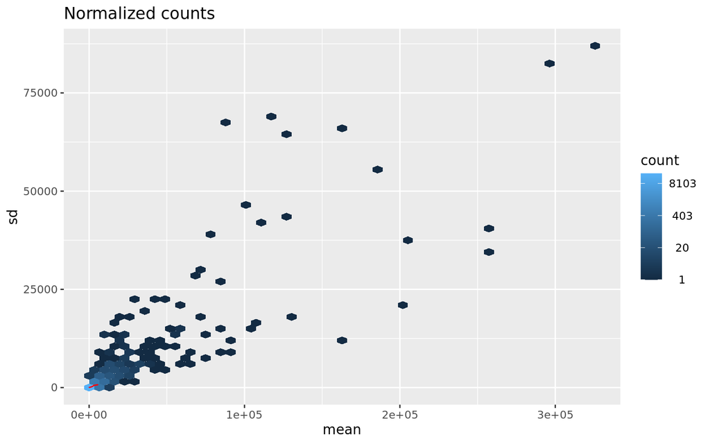

```r
library(ggplot2)

vsn::meanSdPlot(counts(dds, normalized = TRUE) + 1, plot = FALSE, rank = FALSE)$gg + ggtitle("Normalized counts")
```

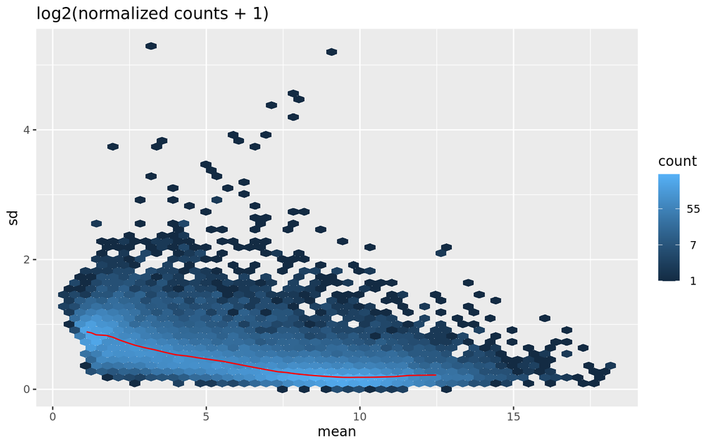

```r
vsn::meanSdPlot((counts(dds, normalized = TRUE) + 1) %>% log2(), plot = FALSE, rank = FALSE)$gg + ggtitle("log2(normalized counts + 1)")
```

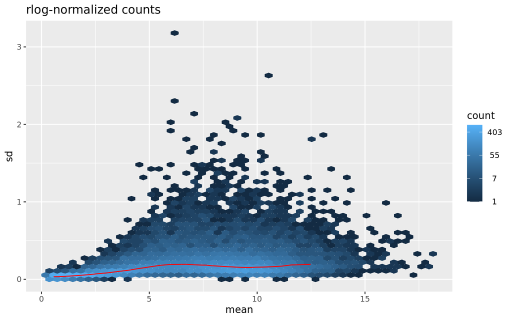

```r
vsn::meanSdPlot(assay(rld), plot = FALSE, rank = FALSE)$gg + ggtitle("rlog-normalized counts")
```

You can see that in normalized, but untransformed counts, genes with the highest mean also have the highest standard deviation. This is the mean-variance trend in RNA-seq data.

Log2 transformation makes it better, but now counts with the smallest values dominate in standard deviation, because log2 amplified their values the most.

Rlog transformation seems to be the best, as it correctly shrunk genes with low counts to average across all samples.

We can also look at a sample-to-sample count plot:

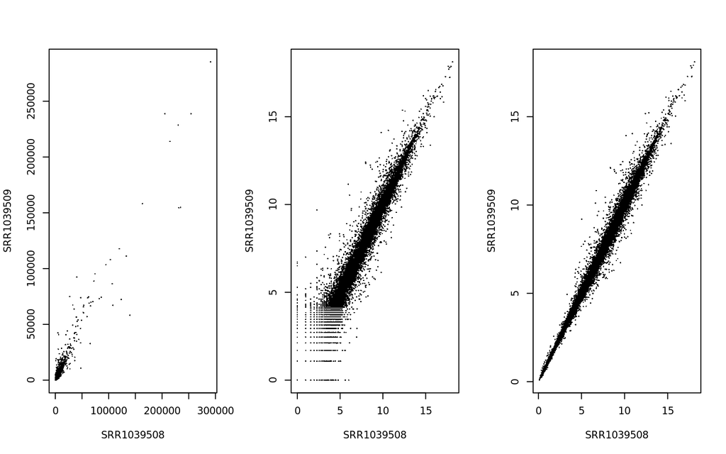

```r
par(mfrow = c(1, 3))
plot(counts(dds, normalized = TRUE)[, 1:2] + 1, pch = 16, cex = 0.3)
plot((counts(dds, normalized = TRUE)[, 1:2] + 1) %>% log2(), pch = 16, cex = 0.3)
plot(assay(rld)[, 1:2], pch = 16, cex = 0.3)
```

Again, the mean-variance trend is visible in untransformed counts. Log2 transformation makes it better, but many low count genes now show the strongest relative differences between samples. Rlog correctly transforms them, as they mean across all samples is very low and they are just a technical noise.

# Exploratory analysis

Exploratory analysis will help us to assess the main characteristics of our data. We can check if our experiment makes sense at biological level and if it was done correctly at technical level. Don’t forget to use the rlog-transformed data (`rld` object), or vsn-transformed data.

## Principal Component Analysis (PCA)

Principal Component Analysis (PCA) is a technique used to emphasize variation and bring out strong patterns in a dataset (dimensionality reduction).

`DESeq2` package has a `plotPCA()` function for that. You can specify the parameter `intgroup` to color points by column from the sample sheet. By default, top 500 most variable genes are used for PCA calculation.

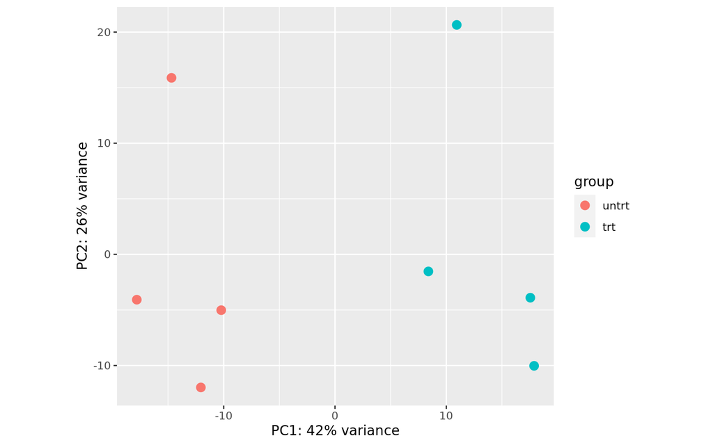

```r
plotPCA(rld, intgroup = "dex")
```

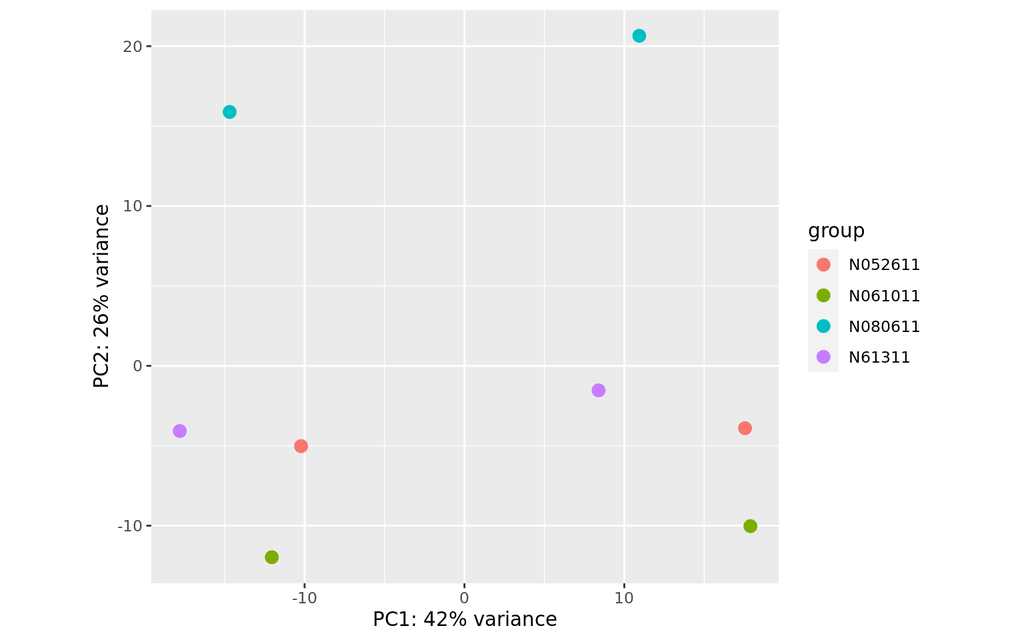

```r
plotPCA(rld, intgroup = "cell")
```

It seems that samples are correctly divided by treatment. There is an evident difference between `N080611` (blue) and other cell lines.

> You should obtain the same PCA plot by using your function and the same number of top most variable genes, e.g. `plot_pca(assay(rld), sample_data = colData(rld), color_by = "dex", n_top_features = 500)`

Note that `plotPCA()` is returning a `ggplot2` object, which can be saved and further modified:

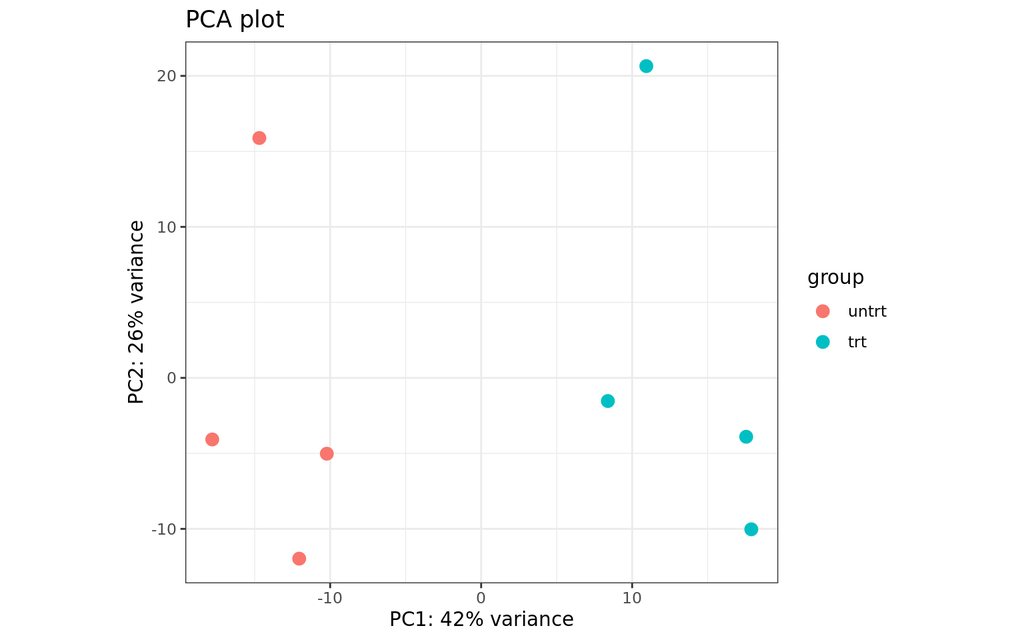

```r
p <- plotPCA(rld, intgroup = "dex")
p + ggtitle("PCA plot") + theme_bw()
```

You can also only return a dataframe with principal components and add more aesthetics to the plot:

```r
p <- plotPCA(rld, intgroup = "dex", returnData = TRUE)
head(p)
```

|  | PC1 | PC2 | group | dex | name |
| --- | --- | --- | --- | --- | --- |
| SRR1039508 | -17.80817 | -4.077440 | untrt | untrt | SRR1039508 |
| SRR1039509 | 8.39146 | -1.533160 | trt | trt | SRR1039509 |
| SRR1039512 | -10.22173 | -5.020959 | untrt | untrt | SRR1039512 |
| SRR1039513 | 17.55166 | -3.899327 | trt | trt | SRR1039513 |
| SRR1039516 | -14.69017 | 15.884637 | untrt | untrt | SRR1039516 |
| SRR1039517 | 10.93834 | 20.646955 | trt | trt | SRR1039517 |

```r
p <- data.frame(p, cell = rld$cell, SampleName = rld$SampleName)
head(p)
```

|  | PC1 | PC2 | group | dex | name | cell | SampleName |
| --- | --- | --- | --- | --- | --- | --- | --- |
| SRR1039508 | -17.80817 | -4.077440 | untrt | untrt | SRR1039508 | N61311 | GSM1275862 |
| SRR1039509 | 8.39146 | -1.533160 | trt | trt | SRR1039509 | N61311 | GSM1275863 |
| SRR1039512 | -10.22173 | -5.020959 | untrt | untrt | SRR1039512 | N052611 | GSM1275866 |
| SRR1039513 | 17.55166 | -3.899327 | trt | trt | SRR1039513 | N052611 | GSM1275867 |
| SRR1039516 | -14.69017 | 15.884637 | untrt | untrt | SRR1039516 | N080611 | GSM1275870 |
| SRR1039517 | 10.93834 | 20.646955 | trt | trt | SRR1039517 | N080611 | GSM1275871 |

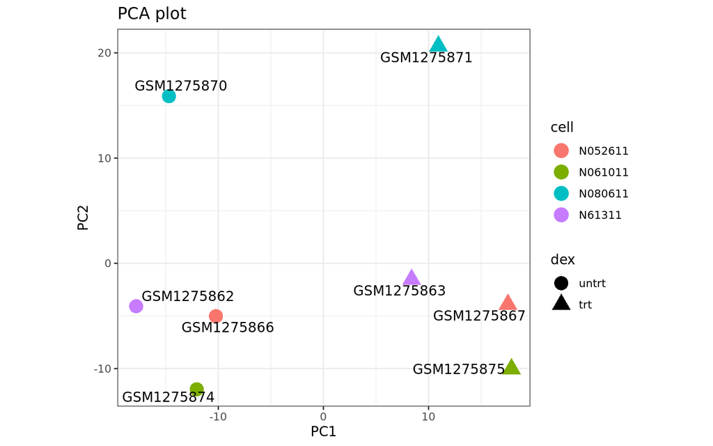

```r
ggplot(p, aes(x = PC1, y = PC2)) +
  # We want to show points, color them by cell and shape them by dex.
  geom_point(aes(color = cell, shape = dex), size = 5) +
  # One unit of x is equal to one unit of y.
  coord_fixed() +
  ggtitle("PCA plot") +
  # Annotate points.
  ggrepel::geom_text_repel(aes(label = SampleName)) +
  # Black and white theme.
  theme_bw()
```

## Hierarchical clustering

Hierarchical clustering is clustering samples by their (Euclidean) distance. Heatmap is used to show how samples are clustered (dendrogram) and what is their distance from each other (colors).

But first we need to calculate a distance matrix of the samples.

```r
sample_dists <- assay(rld) %>% t() %>% dist() %>% as.matrix()
head(sample_dists)
```

```
##            SRR1039508 SRR1039509 SRR1039512 SRR1039513 SRR1039516 SRR1039517 SRR1039520 SRR1039521
## SRR1039508    0.00000   45.76449   39.39689   62.75295   44.67357   64.67402   39.68018   63.48227
## SRR1039509   45.76449    0.00000   55.05195   44.63162   59.22327   51.61886   57.57696   45.15104
## SRR1039512   39.39689   55.05195    0.00000   48.80591   43.73393   59.40815   36.83867   57.99941
## SRR1039513   62.75295   44.63162   48.80591    0.00000   63.88698   50.04076   58.59540   36.58571
## SRR1039516   44.67357   59.22327   43.73393   63.88698    0.00000   47.57564   46.55154   65.69836
## SRR1039517   64.67402   51.61886   59.40815   50.04076   47.57564    0.00000   63.76998   52.48221
```

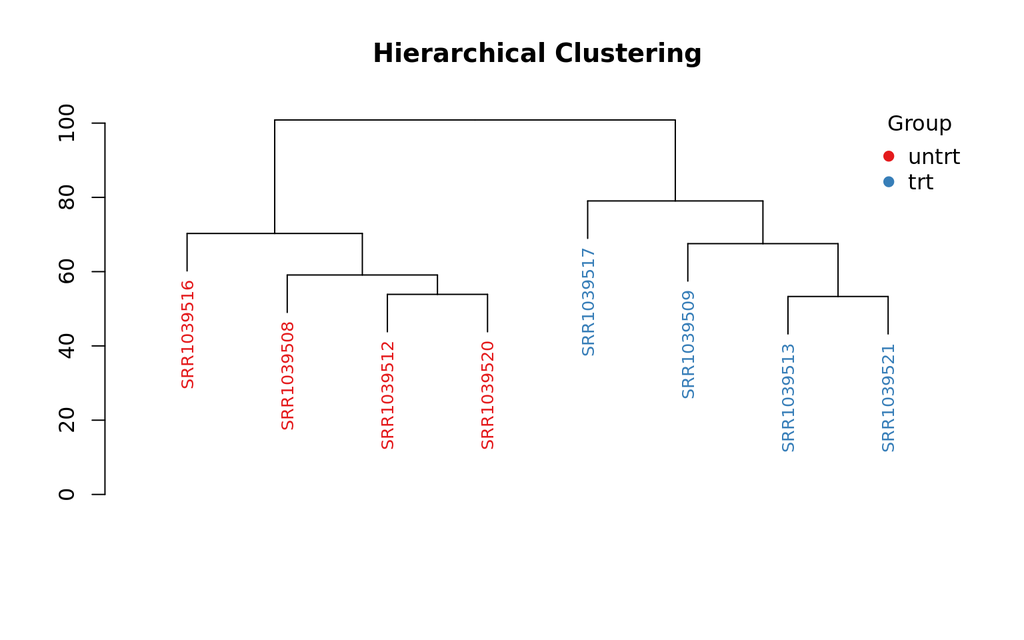

```r
plot_hc(sample_dists, color_by = rld$dex)
```

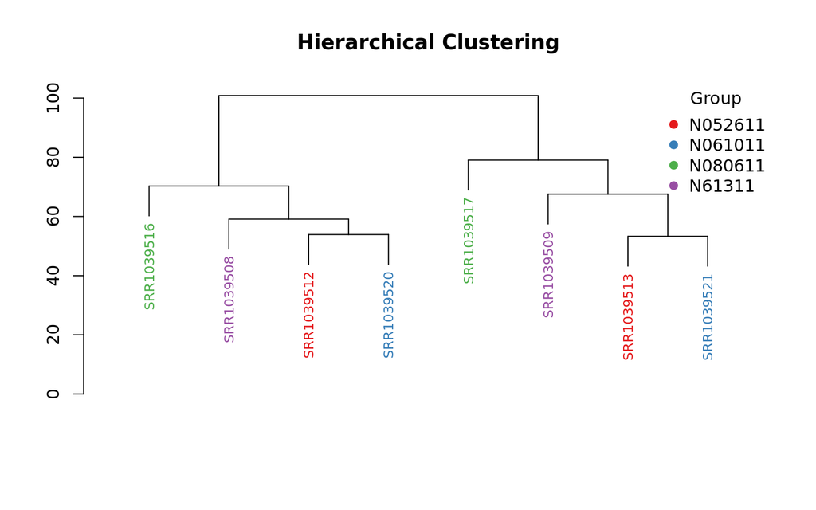

```r
plot_hc(sample_dists, color_by = rld$cell)
```

You can see that clustering of the samples has an interpretable biological meaning - they cluster by the treatment.

Instead of the distance matrix we can also calculate a sample correlation matrix:

```r
sample_cor <- assay(rld) %>% cor()
head(sample_cor)
```

```
##            SRR1039508 SRR1039509 SRR1039512 SRR1039513 SRR1039516 SRR1039517 SRR1039520 SRR1039521
## SRR1039508  1.0000000  0.9963392  0.9972590  0.9931493  0.9964704  0.9926961  0.9972145  0.9930108
## SRR1039509  0.9963392  1.0000000  0.9946907  0.9965371  0.9938568  0.9953551  0.9941910  0.9964658
## SRR1039512  0.9972590  0.9946907  1.0000000  0.9958660  0.9966256  0.9938394  0.9975991  0.9941648
## SRR1039513  0.9931493  0.9965371  0.9958660  1.0000000  0.9929012  0.9956487  0.9940285  0.9976787
## SRR1039516  0.9964704  0.9938568  0.9966256  0.9929012  1.0000000  0.9960654  0.9961697  0.9925133
## SRR1039517  0.9926961  0.9953551  0.9938394  0.9956487  0.9960654  1.0000000  0.9928979  0.9952225
```

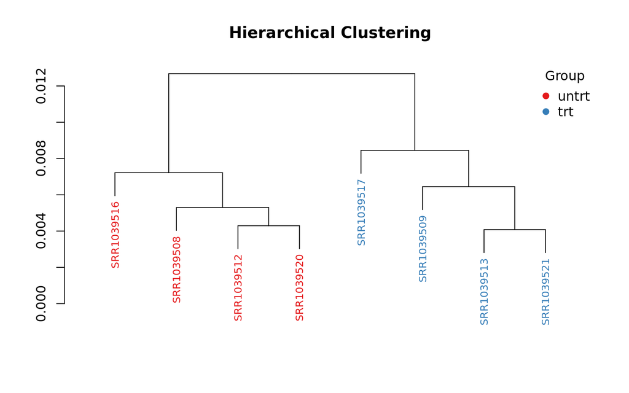

```r
plot_hc(sample_cor, color_by = rld$dex)
```

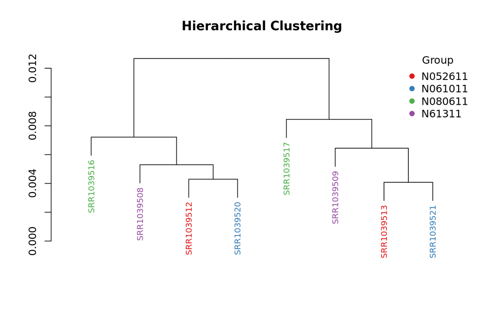

```r
plot_hc(sample_cor, color_by = rld$cell)
```

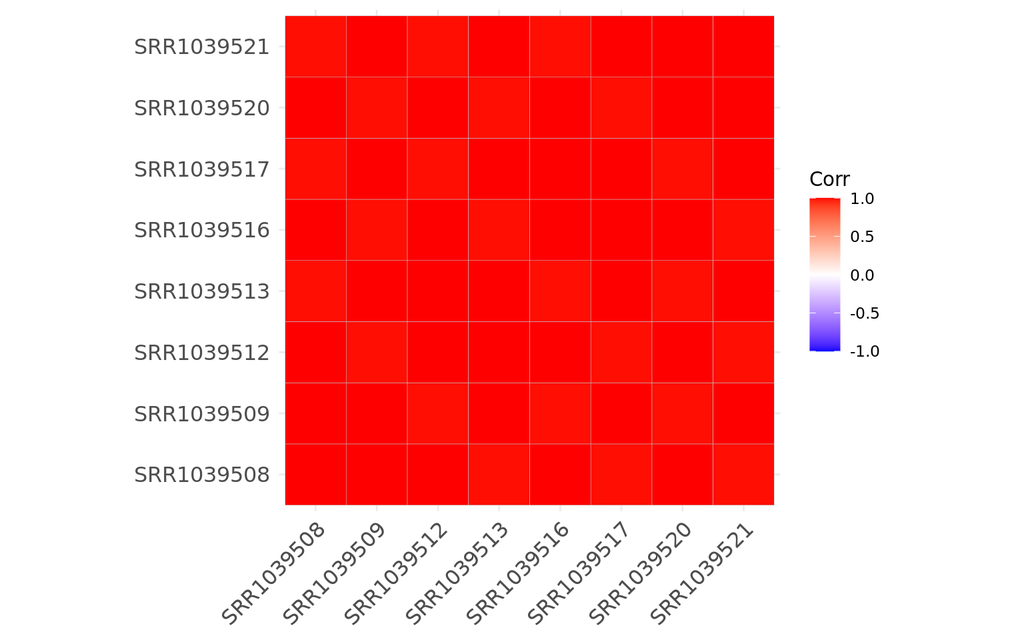

```r
ggcorrplot::ggcorrplot(sample_cor)
```

All samples show pretty high correlations and this suggests there are no outlying samples. Again, they cluster by treatment.

**Together, these plots suggest to us that the data make biologically sense and we can safely proceed to the differential expression analysis (next exercise).**

# Boxplots

Boxplots are a great way to graphically show differences between groups. Rlog-transformed data are used for this purpose. **However, always use a proper statistical model (in our case `DESeq2`) to test for differential expression.** Boxplots are great for exploring, but not objective for assessing the differences.

First we add gene annotation to count matrix and convert it to the long format:

```r
count_matrix <- assay(rld)
count_matrix <- cbind(count_matrix, rowData(rld)[, c("SYMBOL", "GENENAME")]) %>% as.data.frame()
long_data <- tidyr::pivot_longer(
  count_matrix,
  # We want to convert ("expand") these columns to the long format.
  cols = -c(SYMBOL, GENENAME),
  # We want to add observation IDs (colnames) to this column.
  names_to = "sample_id",
  # We want to add observation values (colnames) to this column.
  values_to = "rlog_count"
)

# We can remove the temporary count matrix to free memory.
rm(count_matrix)

head(long_data)
```

| SYMBOL | GENENAME | sample_id | rlog_count |
| --- | --- | --- | --- |
| TSPAN6 | tetraspanin 6 | SRR1039508 | 9.385710 |
| TSPAN6 | tetraspanin 6 | SRR1039509 | 9.052987 |
| TSPAN6 | tetraspanin 6 | SRR1039512 | 9.516677 |
| TSPAN6 | tetraspanin 6 | SRR1039513 | 9.285691 |
| TSPAN6 | tetraspanin 6 | SRR1039516 | 9.838666 |
| TSPAN6 | tetraspanin 6 | SRR1039517 | 9.530143 |

As you can see, for each sample and gene we have its counts and annotation on separated row. But we are still missing the data from the sample sheet. To do it, we will join our long data with the sample sheet, using the `sample_id` column. `left_join(x, y)` function from `dplyr` package is doing that:

> Return all rows from x, and all columns from x and y. Rows in x with no match in y will have NA values in the new columns. If there are multiple matches between x and y, all combinations of the matches are returned.

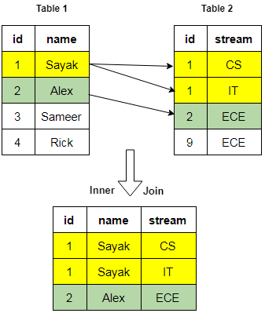

Visual example of joining two tables. `Table 1` and `Table 2` could be our long data and sample sheet. `id` column is similar to our `Sample_ID` column. In the resulting table on bottom, to `Table 1` there are added rows and columns of the rows whose `id` matches in `Table 2`.

```r
sample_sheet <- colData(rld) %>% as.data.frame()
sample_sheet$sample_id <- rownames(sample_sheet)
long_data <- dplyr::left_join(long_data, sample_sheet, by = "sample_id") %>%
  # We will also remove rows with NA gene symbol.
  dplyr::filter(!is.na(SYMBOL))
head(long_data)
```

| SYMBOL | GENENAME | sample_id | rlog_count | SampleName | cell | dex | albut | Run | avgLength | Experiment | Sample | BioSample | sizeFactor |
| --- | --- | --- | --- | --- | --- | --- | --- | --- | --- | --- | --- | --- | --- |
| TSPAN6 | tetraspanin 6 | SRR1039508 | 9.385710 | GSM1275862 | N61311 | untrt | untrt | SRR1039508 | 126 | SRX384345 | SRS508568 | SAMN02422669 | 1.0236767 |
| TSPAN6 | tetraspanin 6 | SRR1039509 | 9.052987 | GSM1275863 | N61311 | trt | untrt | SRR1039509 | 126 | SRX384346 | SRS508567 | SAMN02422675 | 0.8962366 |
| TSPAN6 | tetraspanin 6 | SRR1039512 | 9.516677 | GSM1275866 | N052611 | untrt | untrt | SRR1039512 | 126 | SRX384349 | SRS508571 | SAMN02422678 | 1.1795988 |
| TSPAN6 | tetraspanin 6 | SRR1039513 | 9.285691 | GSM1275867 | N052611 | trt | untrt | SRR1039513 | 87 | SRX384350 | SRS508572 | SAMN02422670 | 0.6699588 |
| TSPAN6 | tetraspanin 6 | SRR1039516 | 9.838666 | GSM1275870 | N080611 | untrt | untrt | SRR1039516 | 120 | SRX384353 | SRS508575 | SAMN02422682 | 1.1776734 |
| TSPAN6 | tetraspanin 6 | SRR1039517 | 9.530143 | GSM1275871 | N080611 | trt | untrt | SRR1039517 | 126 | SRX384354 | SRS508576 | SAMN02422673 | 1.3991183 |

Now our long data are complete and we can proceed to boxplots. Note that we want to work only with several genes at once, and so we have to filter our long data. First we will plot boxplots of cell lines and treatments:

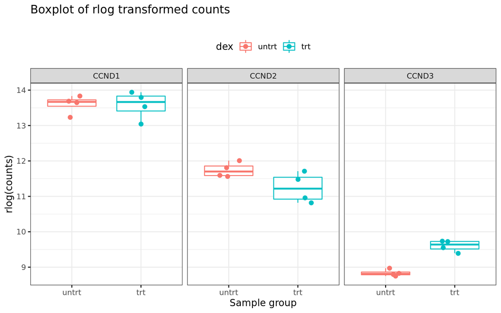

```r
plot_boxplots(
  dplyr::filter(long_data, SYMBOL %in% c("CCND1", "CCND2", "CCND3")),
  x = "dex",
  y = "rlog_count",
  facet_by = "SYMBOL",
  color_by = "dex",
  main = "Boxplot of rlog transformed counts",
  x_lab = "Sample group",
  y_lab = "rlog(counts)",
  do_t_test = FALSE
)
```

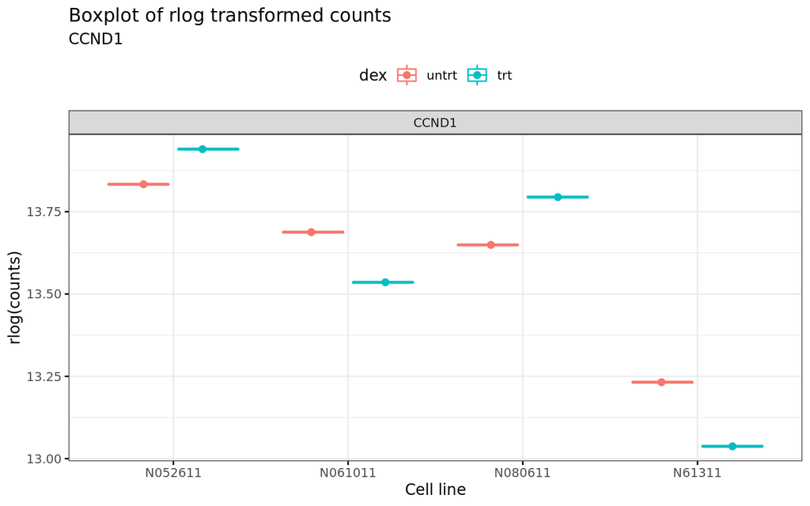

```r
plot_boxplots(
  dplyr::filter(long_data, SYMBOL == "CCND1"),
  x = "cell",
  y = "rlog_count",
  facet_by = "SYMBOL",
  feature = "CCND1",
  color_by = "dex",
  main = "Boxplot of rlog transformed counts",
  x_lab = "Cell line",
  y_lab = "rlog(counts)",
  do_t_test = FALSE
)
```

However, our data contains very few samples in each group, so in this case boxplots don’t make much sense.

# Cleanup

```r
save(list = ls(all.names = TRUE), file = here("E07-RNA_seq/03_exploratory_analysis/03_exploratory_analysis.RData"), envir = environment())

warnings()
traceback()
```

```
## No traceback available
```

# HTML rendering

This chunk is not evaluated (`eval = FALSE`). Otherwise you will probably end up in recursive hell 🤯

```r
library(conflicted)
library(knitr)
library(here)

if (!require(rmdformats)) {
  BiocManager::install("rmdformats")
}

# You can set global chunk options. Options set in individual chunks will override this.
opts_chunk$set(warning = FALSE, message = FALSE, eval = TRUE)
rmarkdown::render(
  here("E07-RNA_seq/03_exploratory_analysis/03_exploratory_analysis.Rmd"),
  output_file = here("E07-RNA_seq/03_exploratory_analysis/03_exploratory_analysis.html"),
  envir = new.env(),
  knit_root_dir = here()
)
```